# CUT&RUN downstream analysis

# Analysis summary

**GSE186608 HCT116 H3K27ac CUT&RUN downstream reanalysis**  
**Data status:** PUBLIC DATA REANALYSIS - GSE186608 HCT116 H3K27ac

This report starts from an explicit consensus-peak-by-sample integer count matrix. It does not call peaks, count BAM files, reproduce alignment QC, or run DiffBind.

Contrast-level result ledger summary

| contrast | input_rows | retained_rows | finite_pvalue | finite_padj | significant | increased | decreased | all_zero | low_count_filtered | unavailable | independent_filtered | tested_nonsignificant | alpha | p_adjust_method | independent_filtering | filter_threshold | bh_scope |
| --- | --- | --- | --- | --- | --- | --- | --- | --- | --- | --- | --- | --- | --- | --- | --- | --- | --- |
| cobimetinib_vs_untreated | 38649 | 38649 | 31730 | 26257 | 2743 | 1084 | 1659 | 6919 | 0 | 0 | 5473 | 23514 | 0.05 | BH | TRUE | 17.2990 | one DESeq2 contrast among retained rows passing the selected independent-filter threshold with finite raw p-values |
| TNFalpha_vs_untreated | 38649 | 38649 | 31730 | 24433 | 914 | 802 | 112 | 6919 | 0 | 0 | 7297 | 23519 | 0.05 | BH | TRUE | 22.5207 | one DESeq2 contrast among retained rows passing the selected independent-filter threshold with finite raw p-values |

Every input region remains in each result export. Missing adjusted p-values are not called non-significant: all_zero, low_count_filtered, unavailable, and independent_filtered are explicit. Benjamini-Hochberg adjustment and DESeq2 independent filtering are performed separately for each contrast.

# Inputs, model, and normalization boundary

Resolved run metadata

| field | value |
| --- | --- |
| project | GSE186608 HCT116 H3K27ac CUT&RUN downstream reanalysis |
| data_status | PUBLIC DATA REANALYSIS - GSE186608 HCT116 H3K27ac |
| genome_build | hg38 |
| input_coordinate_system | bed_zero_based_half_open |
| analysis_coordinate_system | one_based_closed |
| design | ~ condition |
| normalization | deseq2_median_ratio |
| minimum_total_count | 0 |
| fdr | 0.05 |
| input_peaks | 38649 |
| retained_peaks | 38649 |
| samples | 6 |
| annotation_enabled | TRUE |
| generated_utc | 2026-10-02 22:31:20 UTC |
| provenance_accession | GSE186608 |
| provenance_citation | Ivancevic et al., Science Advances (2024) |
| provenance_doi | 10.1126/sciadv.ado1218 |
| provenance_archive | https://zenodo.org/records/10996183 |
| provenance_source_tag | v1.0 |
| provenance_source_commit | faeef682bebdfb982c70b47a5d7df4ac77f61264 |
| provenance_source_license | CC BY 4.0 |
| provenance_counting_unit | bedtools multicov aligned-read overlaps |
| provenance_region_set | union of per-sample top-20k peak sets |
| provenance_inference_limit | n=2 treatment replicates per condition; relative signal only |

Sample metadata

|  | condition | plot_label | geo_accession | source_note |
| --- | --- | --- | --- | --- |
| UT_K27ac_rep1 | untreated | UT1 | GSM5657497 | treatment replicate 1 |
| UT_K27ac_rep2 | untreated | UT2 | GSM5657498 | treatment replicate 2; source reports resequenced/merged |
| Cobi_K27ac_rep1 | cobimetinib | Cobi1 | GSM5657501 | treatment replicate 1 |
| Cobi_K27ac_rep2 | cobimetinib | Cobi2 | GSM5657502 | treatment replicate 2 |
| TNFa_K27ac_rep1 | TNFalpha | TNFa1 | GSM5657505 | treatment replicate 1 |
| TNFa_K27ac_rep2 | TNFalpha | TNFa2 | GSM5657506 | treatment replicate 2 |

Declared comparisons

| label | factor | numerator | denominator |
| --- | --- | --- | --- |
| cobimetinib_vs_untreated | condition | cobimetinib | untreated |
| TNFalpha_vs_untreated | condition | TNFalpha | untreated |

Size factors used in the fitted model

|  | sample_id | deseq2_size_factor |
| --- | --- | --- |
| UT_K27ac_rep1 | UT_K27ac_rep1 | 1.8328 |
| UT_K27ac_rep2 | UT_K27ac_rep2 | 0.3458 |
| Cobi_K27ac_rep1 | Cobi_K27ac_rep1 | 1.3679 |
| Cobi_K27ac_rep2 | Cobi_K27ac_rep2 | 1.0108 |
| TNFa_K27ac_rep1 | TNFa_K27ac_rep1 | 1.2523 |
| TNFa_K27ac_rep2 | TNFa_K27ac_rep2 | 0.9447 |

Only the coordinate columns plus sample IDs declared in metadata are accepted from the count matrix; unexpected columns cause an error rather than silently becoming count columns. Root-relative paths are resolved from the repository root. Numeric-only categorical codes are rejected.

DESeq2 median-of-ratios normalization estimates **relative** occupancy and assumes most retained peaks do not shift together. Without spike-in or another external scale, this analysis cannot establish a global gain or loss of signal.

# Sample diagnostics

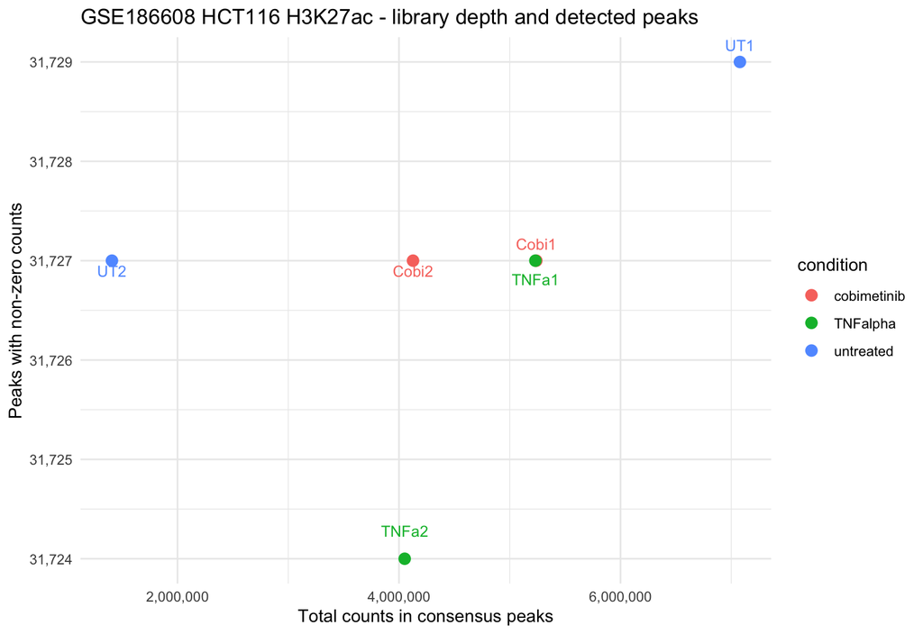

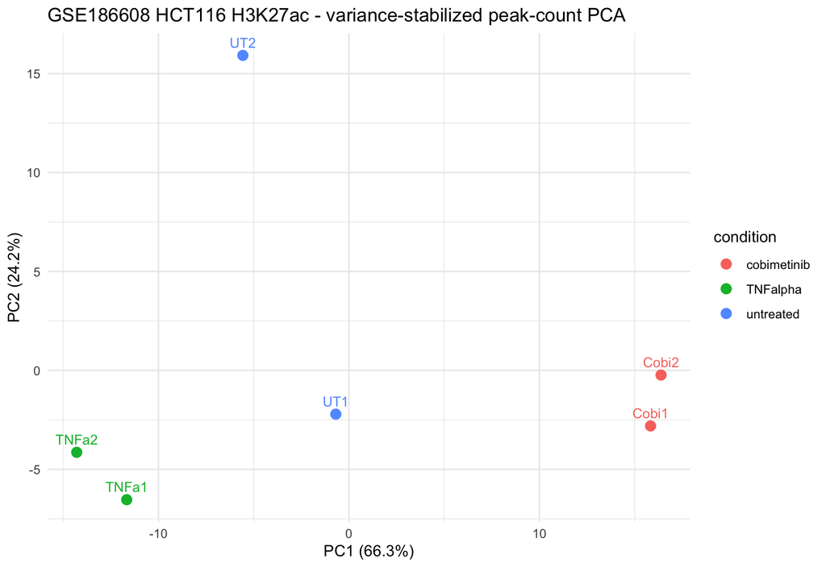

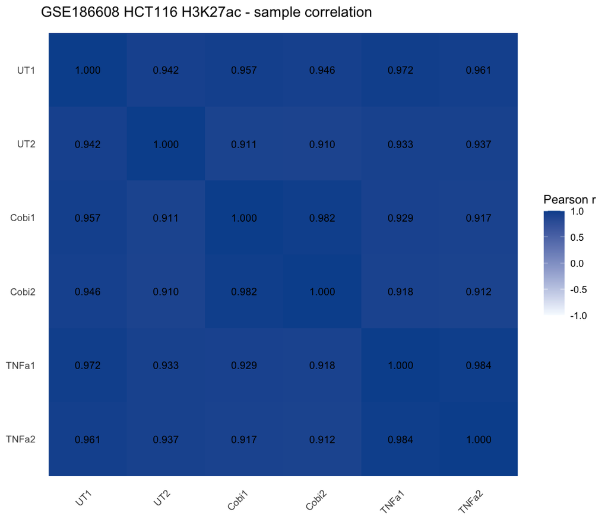

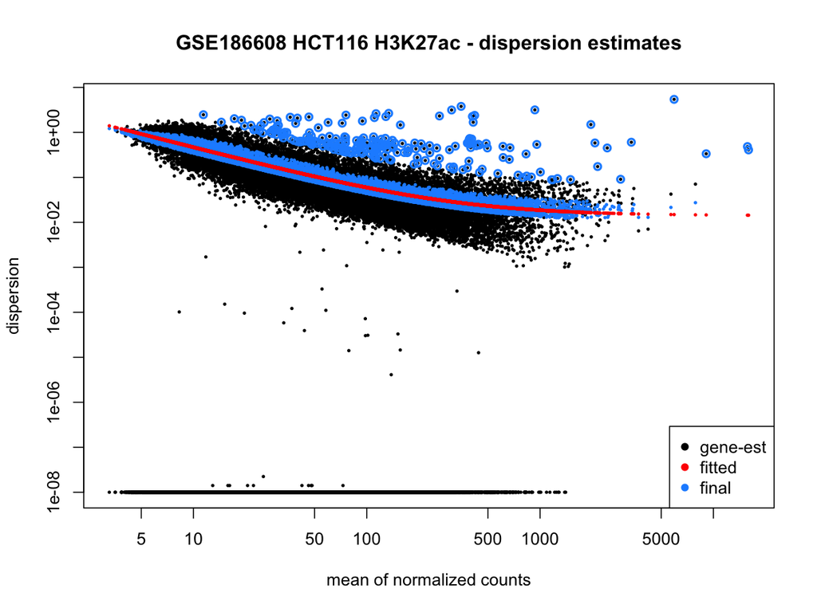

No samples are excluded automatically from these diagnostics. In the public example each condition has only two biological replicates; the separated untreated pair is retained as observed. With n=2 per condition, sample-level influence judgments are fragile, and standard Cook’s-distance replacement is not available as it is for larger replicate groups.

# Differential peaks

## cobimetinib_vs_untreated

| contrast | input_rows | retained_rows | finite_pvalue | finite_padj | significant | increased | decreased | all_zero | low_count_filtered | unavailable | independent_filtered | tested_nonsignificant | alpha | p_adjust_method | independent_filtering | filter_threshold | bh_scope |
| --- | --- | --- | --- | --- | --- | --- | --- | --- | --- | --- | --- | --- | --- | --- | --- | --- | --- |
| cobimetinib_vs_untreated | 38649 | 38649 | 31730 | 26257 | 2743 | 1084 | 1659 | 6919 | 0 | 0 | 5473 | 23514 | 0.05 | BH | TRUE | 17.299 | one DESeq2 contrast among retained rows passing the selected independent-filter threshold with finite raw p-values |

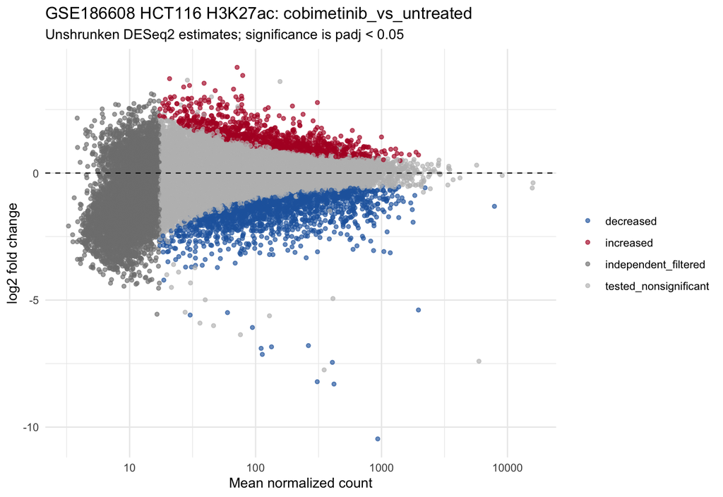

## TNFalpha_vs_untreated

|  | contrast | input_rows | retained_rows | finite_pvalue | finite_padj | significant | increased | decreased | all_zero | low_count_filtered | unavailable | independent_filtered | tested_nonsignificant | alpha | p_adjust_method | independent_filtering | filter_threshold | bh_scope |
| --- | --- | --- | --- | --- | --- | --- | --- | --- | --- | --- | --- | --- | --- | --- | --- | --- | --- | --- |
| 2 | TNFalpha_vs_untreated | 38649 | 38649 | 31730 | 24433 | 914 | 802 | 112 | 6919 | 0 | 0 | 7297 | 23519 | 0.05 | BH | TRUE | 22.5207 | one DESeq2 contrast among retained rows passing the selected independent-filter threshold with finite raw p-values |

[figure not shown]

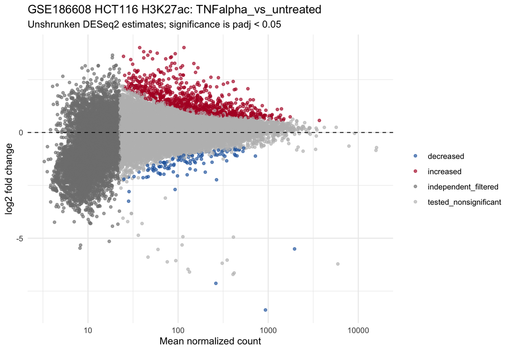

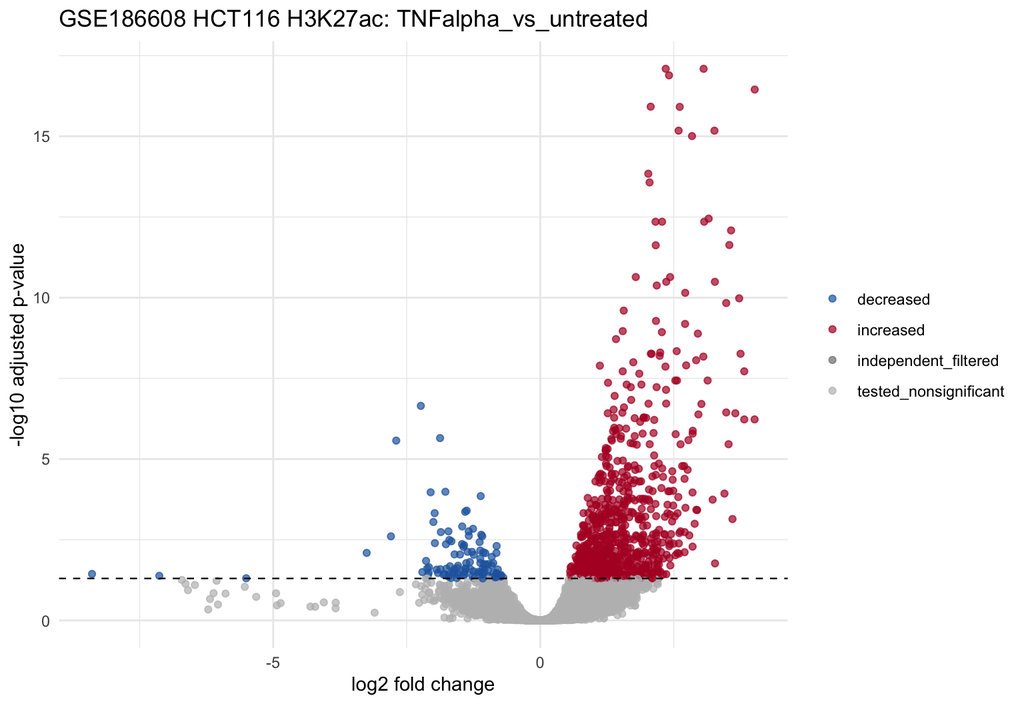

# Genomic annotation

Annotation coverage

| input_peaks | annotated_category | gene_id_assigned | symbol_assigned | distance_to_tss_available |
| --- | --- | --- | --- | --- |
| 38649 | 38644 | 38644 | 38634 | 38644 |

Annotation used TxDb.Hsapiens.UCSC.hg38.knownGene and org.Hs.eg.db. Genome build and seqnames were validated. Each contrast export includes annotation category, nearest gene fields, and distanceToTSS.

# Interpretation boundary

The exported tables support review of relative differential peaks, annotation, and replicate patterns. The workflow intentionally omits exploratory derivative networks, online enrichment, WikiPathways, Cytoscape examples, cross-mark analyses, and repeat-family/LTR10 expansion; each would need a separately declared design and reference provenance.

# Downloads and reproducibility

This saved portfolio snapshot links only to compact tracked results. Full tables are regenerated under the configured output directory.

- Contrast summary
- Top significant-region snapshot

The manifests record resolved input paths and SHA-256 hashes, code hashes, resolved configuration, software versions, warnings, and the full R session. They document the executed environment without claiming an automatically restorable lockfile.